# 机器学习——Keras 建模通用步骤

在使用Keras进行机器学习建模的时候，有一些通用的步骤。我们可以简单归纳如下：

1. 定义问题和要训练的数据 收集这些数据，如果有必要的话运用标签来标注数据。
2. 选择衡量问题成功的指标。 包括从各种地方下载数据集，自己处理数据等。
3. 确定评估方法 留出验证？K折验证？我应该将那一部分数据用于验证？
4. 准备数据
5. 开发一个笔基准更好的模型，也就是具有统计功效的模型。
6. 开发过拟合的模型
7. 基于模型在验证数据上的性能来进行模型正则化和调节超参数。

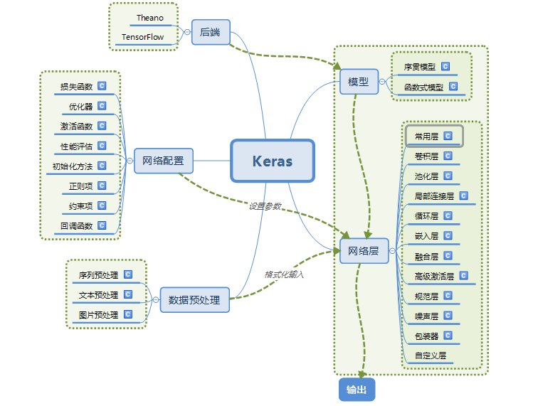

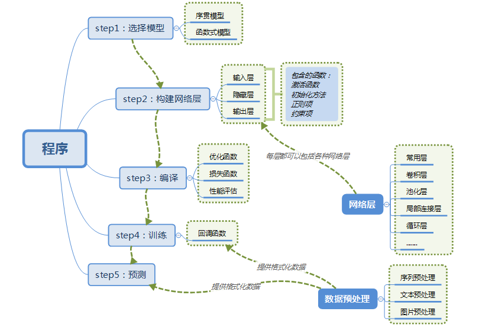

# 1. 定义问题和要训练的数据

[output not shown]

# 2. 选择衡量问题成功的指标。

```
要取得成功，就必须得到成功的定义。精度？召回率？准确率？客户保留率？衡量成功的指标将只因你选择损失函数，也就是模型要优化什么。
```

# 3. 确定评估方法

```
评估模型的重点是将数据划分为三个集合：训练集、验证集和测试集。

方法有三种： 数据多的时候用简单的“留出验证”
           数据中的时候K折交叉验证
           数据少的时候用带有打乱数据的重复K折验证
```

```python
# 简单的留出验证
num_validation_samples = 10000

np.random.shuffle(data)#打乱数据

validation_data = data[:num_validation_samples]#定义验证集
data = data[num_validation_samples:]

training_data = data[:]#定义训练集

#在训练数据上训练模型，并且在验证数据上评估模型
model = get_model()
model.train(training_data)
validation_score = model.evaluate(validation_data)

#调节模型，重新训练、评估，然后再次调节。

#一旦调节好超参数，通常就在所有非测试模型数据上从头开始训练最终模型。
model = get_model
model.train(np.concatenate([training_data,
                           validation_data]))
test_score = model.evaluate(test_data)
```

```python
#K折验证
```

[output not shown]

[output not shown]

# 4. 数据准备

```
# 4.1 数据预处理
神经网络的数据预处理目的是是的原始数据都更加适用于神经网络，包括向量化、标准化、处理缺失值 和 特征提取。

4.1.1 向量化
神经网络的输入和木笔啊必须都是 浮点数张量 。无论处理什么数据（声音、图像还是文本），都需要先转换为张量，这一部叫做数据向量化（data vectorization).
```

```python
    #向量化
import numpy as np

def vectorize_sequences(sequences, dimention = 10000):

    results = np.zreos(len(sequences), dimention)#创建一个形状为len(sequences), dimention的零矩阵。

    for i, sequences in enumerate(sequences):
        results[i,sequence] = i
    return results

x_train = vectorize_sequences(train_data)
x_test = vectorize_sequence(test_data)
```

```
4.1.2 值标准化
一般来说，将取值相对较大的数据（比如多位整数，比网络全中初始值大很多）或者异质数据(heterogeneous data, 比如数据的一个特征在0-1范围内，另一个特征在100-200范围内）输入到神经网络中是不安全的。属于数据应该需要以下特征：
1. 取值较小（0-1）
2. 同质性（homogeneous）
因此我们要对每一个特征进行标准化处理。
```

```python
    #值标准化
import numpy as np

def standardize(x)
    x -= x.mean(axis = 0)
    x /= x.std(axis = 0)
    return x
    #假设x是一个形状为（samples, features） 的二维矩阵。

train_data.standardize()
test_data.standardize()
```

```
4.1.3 处理缺失值
一般来说，将缺失值处理为0是安全的，如果0 没有很显著的意义的话。
网络可以从中学习到0 是缺失值， 并且会自动忽略这个值。
```

```
4.1.4 特征工程
特征工程就是对于特征，我们用更好的办法、结构来指代。比如对于钟表，究竟是直角坐标系更有利，还是极坐标更有利呢？
```

# 5、6、7 调整模型

```
这主要是选择参数和模型结构。此处重点讲一下：如何应对过拟合
0. 获取更多训练数据
    这个解决方法可遇不可求。

1. 减小网络大小
    也就是Dense层第一个参数减小。

2. 权重正则化
    l1 范数 或者l2范数

3. dropout正则化
    dropout比率通常在0.2 - 0.5
```

```python
# keras中不同的权重正则化项
from keras import regularizers

regularizers.l1(0.001) # L1正则化

regularizers.l1_l2(li = 0.001, l2 = 0.001)#同时做 L1和 L2正则化

#添加权重正则化：使用Dense层中的kernel_regularizer参数。
model.add(layers.Dense(16,kernel_regularizer = regularizers.l2(0.001),
                      activation = 'relu', input_shape = (10000,)))

#l2 的意思是：
#该层权重矩阵的每个系数都会使得网络总损失增加0.001*weight_coefficient_value
#注意：由于这个惩罚 只在训练时增加，所以这个网络饿训练损失会笔测试损失大很多。
```

```python
#dropout正则化层
model.add(layers.Dropout(0.5))
```

# 附1: 模型种类选择和模型编译

```
模型种类选择：序贯模型还是函数式模型

模型编译：需要确定 最后一层激活、优化、损失函数和指标（比如精度）

最后一层激活：对网络输出进行有效的限制。
损失函数：应该匹配你要解决的问题。
优化配置：一般情况下使用 rmsprop和 默认的学习旅都是稳妥的。

下表是 不同问题类型 对应的最后一层激活层和损失函数的选择。

    问题类型              最后一层激活                 损失函数
二分类问题                  sigmoid           binary_crossentropy
多分类、单标签问题           softmax           categorical_crossentropy
多分类、多标签问题           sigmoid           binary_crossentropy
回归到任意值                   无              mse
回归到0-1范围内的值          sigmoid           mse 或 binary_crossentropy
```

```python
#序贯模型
model = model.Sequences()
```

```python
#模型编译
model.compile(optimizer = optimizers.RMSprop(lr = 0.001),
              loss = 'binary_crossentropy'
              metrics = ['accuracy'])

#自定义模型参数
model.compile(optimizers = optimizers.RMSprop(lr = 0.01)
              loss = loss.binary_crossentropy
              metrics = [metrics.binary_accuracy])
```

# 附2: 模型层选择

```
图像问题：卷积神经网络（CNN）
CNN需要两个层配合使用：卷积层 和 池化层。

自然语言 和 序列问题：
        如果没有时间要求：CNN
        如果有时间要求，且序列数量比较小：RNN（比如SimpleRNN）
        如果有时间要求，且序列数量比较大：CNN预处理+RNN
RNN：SimpleRNN，LSTM，GRU 后两者为了解决前者的梯度消失问题。


处理文本数据：使用词嵌入（Embedding层学习词嵌入）
```

# 附3: keras的常见层

## 一、网络层

keras的层主要包括：

常用层（Core）、卷积层（Convolutional）、池化层（Pooling）、局部连接层、递归层（Recurrent）、嵌入层（ Embedding）、高级激活层、规范层、噪声层、包装层，当然也可以编写自己的层。

对于层的操作

layer.get_weights() #返回该层的权重（numpy array） layer.set_weights(weights)#将权重加载到该层 config = layer.get_config()#保存该层的配置 layer = layer_from_config(config)#加载一个配置到该层

# 如果层仅有一个计算节点（即该层不是共享层），则可以通过下列方法获得输入张量、输出张量、输入数据的形状和输出数据的形状：

layer.input layer.output layer.input_shape layer.output_shape

# 如果该层有多个计算节点。可以使用下面的方法

layer.get_input_at(node_index) layer.get_output_at(node_index) layer.get_input_shape_at(node_index) layer.get_output_shape_at(node_index)

## 1、常用网络层

#### 1.1、Dense层(全连接层）

keras.layers.core.Dense(units,activation=None,use_bias=True,kernel_initializer='glorot_uniform',bias_initializer='zeros',kernel_regularizer=None,bias_regularizer=None,activity_regularizer=None,kernel_constraint=None,bias_constraint=None) 参数：

#### 1.2、Activation层

keras.layers.core.Activation(activation) 激活层对一个层的输出施加激活函数

参数：

activation：将要使用的激活函数，为预定义激活函数名或一个Tensorflow/Theano的函数。参考激活函数 输入shape：任意，当使用激活层作为第一层时，要指定input_shape 输出shape：与输入shape相同

#### 1.3、dropout层

keras.layers.core.Dropout(rate, noise_shape=None, seed=None) 1 为输入数据施加Dropout。Dropout将在训练过程中每次更新参数时按一定概率（rate）随机断开输入神经元，Dropout层用于防止过拟合。

参数

rate：0~1的浮点数，控制需要断开的神经元的比例 noise_shape：整数张量，为将要应用在输入上的二值Dropout mask的shape，例如你的输入为(batch_size, timesteps, features)，并且你希望在各个时间步上的Dropout mask都相同，则可传入noise_shape=(batch_size, 1, features)。 seed：整数，使用的随机数种子 1.4、Flatten层

keras.layers.core.Flatten()

Flatten层用来将输入“压平”，即把多维的输入一维化，常用在从卷积层到全连接层的过渡。Flatten不影响batch的大小。

demo：

model = Sequential() model.add(Convolution2D(64, 3, 3, border_mode='same', input_shape=(3, 32, 32))) \ now: model.output_shape == (None, 64, 32, 32)

model.add(Flatten()) \ now: model.output_shape == (None, 65536)

#### 1.5、Reshape层

keras.layers.core.Reshape(target_shape) 1 Reshape层用来将输入shape转换为特定的shape

参数

target_shape：目标shape，为整数的tuple，不包含样本数目的维度（batch大小） 输入shape：任意，但输入的shape必须固定。当使用该层为模型首层时，需要指定input_shape参数 输出shape：(batch_size,)+target_shape

demo：

\ as first layer in a Sequential model model = Sequential() model.add(Reshape((3, 4), input_shape=(12,))) \ now: model.output_shape == (None, 3, 4) \ note: `None` is the batch dimension

\ as intermediate layer in a Sequential model model.add(Reshape((6, 2))) \ now: model.output_shape == (None, 6, 2)

\ also supports shape inference using `-1` as dimension model.add(Reshape((-1, 2, 2))) \ now: model.output_shape == (None, 3, 2, 2)

#### 1.6、Permute层

keras.layers.core.Permute(dims)

Permute层将输入的维度按照给定模式进行重排，例如，当需要将RNN和CNN网络连接时，可能会用到该层。所谓的重排也就是交换两行

参数

dims：整数tuple，指定重排的模式，不包含样本数的维度。重拍模式的下标从1开始。例如（2，1）代表将输入的第二个维度重排到输出的第一个维度，而将输入的第一个维度重排到第二个维度 model = Sequential() model.add(Permute((2, 1), input_shape=(10, 64))) \ now: model.output_shape == (None, 64, 10) \ note: `None` is the batch dimension

输入shape：任意，当使用激活层作为第一层时，要指定input_shape 输出shape：与输入相同，但是其维度按照指定的模式重新排列

#### 1.7、RepeatVector层

keras.layers.core.RepeatVector(n)

RepeatVector层将输入重复n次

参数

n：整数，重复的次数 输入shape：形如（nb_samples, features）的2D张量 输出shape：形如（nb_samples, n, features）的3D张量

例子

model = Sequential() model.add(Dense(32, input_dim=32)) \ now: model.output_shape == (None, 32) \ note: `None` is the batch dimension

model.add(RepeatVector(3)) \ now: model.output_shape == (None, 3, 32)

#### 1.8、Lambda层

keras.layers.core.Lambda(function, output_shape=None, mask=None, arguments=None) 1 本函数用以对上一层的输出施以任何Theano/TensorFlow表达式

参数

function：要实现的函数，该函数仅接受一个变量，即上一层的输出 output_shape：函数应该返回的值的shape，可以是一个tuple，也可以是一个根据输入 shape计算输出shape的函数 mask: 掩膜 arguments：可选，字典，用来记录向函数中传递的其他关键字参数 输入shape：任意，当使用该层作为第一层时，要指定input_shape 输出shape：由output_shape参数指定的输出shape，当使用tensorflow时可自动推断

\ add a x -> x^2 layer model.add(Lambda(lambda x: x ** 2))

\ add a layer that returns the concatenation \ of the positive part of the input and \ the opposite of the negative part

def antirectifier(x): x -= K.mean(x, axis=1, keepdims=True) x = K.l2_normalize(x, axis=1) pos = K.relu(x) neg = K.relu(-x) return K.concatenate([pos, neg], axis=1)

def antirectifier_output_shape(input_shape): shape = list(input_shape) assert len(shape) == 2 # only valid for 2D tensors shape[-1] *= 2 return tuple(shape)

model.add(Lambda(antirectifier, output_shape=antirectifier_output_shape))

#### 1.9、ActivityRegularizer层

keras.layers.core.ActivityRegularization(l1=0.0, l2=0.0)

经过本层的数据不会有任何变化，但会基于其激活值更新损失函数值

参数

l1：1范数正则因子（正浮点数） l2：2范数正则因子（正浮点数） 输入shape：任意，当使用该层作为第一层时，要指定input_shape 输出shape：与输入shape相同

#### 2.0、Masking层

keras.layers.core.Masking(mask_value=0.0)

## 2、卷积层Convolutional

#### 2.1、Conv1D层

keras.layers.convolutional.Conv1D(filters, kernel_size, strides=1, padding='valid', dilation_rate=1, activation=None, use_bias=True, kernel_initializer='glorot_uniform', bias_initializer='zeros', kernel_regularizer=None, bias_regularizer=None, activity_regularizer=None, kernel_constraint=None, bias_constraint=None) 1 一维卷积层（即时域卷积），用以在一维输入信号上进行邻域滤波。当使用该层作为首层时，需要提供关键字参数input_shape。例如(10,128)代表一个长为10的序列，序列中每个信号为128向量。而(None, 128)代表变长的128维向量序列。

该层生成将输入信号与卷积核按照单一的空域（或时域）方向进行卷积。如果use_bias=True，则还会加上一个偏置项，若activation不为None，则输出为经过激活函数的输出。

参数

filters：卷积核的数目（即输出的维度） kernel_size：整数或由单个整数构成的list/tuple，卷积核的空域或时域窗长度 strides：整数或由单个整数构成的list/tuple，为卷积的步长。任何不为1的strides均与任何不为1的dilation_rate均不兼容 padding：补0策略，为“valid”, “same” 或“causal”，“causal”将产生因果（膨胀的）卷积，即output[t]不依赖于input[t+1：]。当对不能违反时间顺序的时序信号建模时有用。参考WaveNet: A Generative Model for Raw Audio, section 2.1.。“valid”代表只进行有效的卷积，即对边界数据不处理。“same”代表保留边界处的卷积结果，通常会导致输出shape与输入shape相同。 activation：激活函数，为预定义的激活函数名（参考激活函数），或逐元素（element-wise）的Theano函数。如果不指定该参数，将不会使用任何激活函数（即使用线性激活函数：a(x)=x） dilation_rate：整数或由单个整数构成的list/tuple，指定dilated convolution中的膨胀比例。任何不为1的dilation_rate均与任何不为1的strides均不兼容。 use_bias:布尔值，是否使用偏置项 kernel_initializer：权值初始化方法，为预定义初始化方法名的字符串，或用于初始化权重的初始化器。参考initializers bias_initializer：权值初始化方法，为预定义初始化方法名的字符串，或用于初始化权重的初始化器。参考initializers kernel_regularizer：施加在权重上的正则项，为Regularizer对象 bias_regularizer：施加在偏置向量上的正则项，为Regularizer对象 activity_regularizer：施加在输出上的正则项，为Regularizer对象 kernel_constraints：施加在权重上的约束项，为Constraints对象 bias_constraints：施加在偏置上的约束项，为Constraints对象 输入shape：形如（samples，steps，input_dim）的3D张量 输出shape：形如（samples，new_steps，nb_filter）的3D张量，因为有向量填充的原因，steps的值会改变

#### 2.2、Conv2D层

keras.layers.convolutional.Conv2D(filters, kernel_size, strides=(1, 1), padding='valid', data_format=None, dilation_rate=(1, 1), activation=None, use_bias=True, kernel_initializer='glorot_uniform', bias_initializer='zeros', kernel_regularizer=None, bias_regularizer=None, activity_regularizer=None, kernel_constraint=None, bias_constraint=None) 1 二维卷积层，即对图像的空域卷积。该层对二维输入进行滑动窗卷积，当使用该层作为第一层时，应提供input_shape参数。例如input_shape = (128,128,3)代表128*128的彩色RGB图像（data_format='channels_last'）

参数

filters：卷积核的数目（即输出的维度） kernel_size：单个整数或由两个整数构成的list/tuple，卷积核的宽度和长度。如为单个整数，则表示在各个空间维度的相同长度。 strides：单个整数或由两个整数构成的list/tuple，为卷积的步长。如为单个整数，则表示在各个空间维度的相同步长。任何不为1的strides均与任何不为1的dilation_rate均不兼容 padding：补0策略，为“valid”, “same” 。“valid”代表只进行有效的卷积，即对边界数据不处理。“same”代表保留边界处的卷积结果，通常会导致输出shape与输入shape相同。 activation：激活函数，为预定义的激活函数名（参考激活函数），或逐元素（element-wise）的Theano函数。如果不指定该参数，将不会使用任何激活函数（即使用线性激活函数：a(x)=x） dilation_rate：单个整数或由两个整数构成的list/tuple，指定dilated convolution中的膨胀比例。任何不为1的dilation_rate均与任何不为1的strides均不兼容。 data_format：字符串，“channels_first”或“channels_last”之一，代表图像的通道维的位置。该参数是Keras 1.x中的image_dim_ordering，“channels_last”对应原本的“tf”，“channels_first”对应原本的“th”。以128x128的RGB图像为例，“channels_first”应将数据组织为（3,128,128），而“channels_last”应将数据组织为（128,128,3）。该参数的默认值是~/.keras/keras.json中设置的值，若从未设置过，则为“channels_last”。 use_bias:布尔值，是否使用偏置项 kernel_initializer：权值初始化方法，为预定义初始化方法名的字符串，或用于初始化权重的初始化器。参考initializers bias_initializer：权值初始化方法，为预定义初始化方法名的字符串，或用于初始化权重的初始化器。参考initializers kernel_regularizer：施加在权重上的正则项，为Regularizer对象 bias_regularizer：施加在偏置向量上的正则项，为Regularizer对象 activity_regularizer：施加在输出上的正则项，为Regularizer对象 kernel_constraints：施加在权重上的约束项，为Constraints对象 bias_constraints：施加在偏置上的约束项，为Constraints对象 输入shape： ‘channels_first’模式下，输入形如（samples,channels，rows，cols）的4D张量。 ‘channels_last’模式下，输入形如（samples，rows，cols，channels）的4D张量。

输出shape： ‘channels_first’模式下，为形如（samples，nb_filter, new_rows, new_cols）的4D张量。 ‘channels_last’模式下，为形如（samples，new_rows, new_cols，nb_filter）的4D张。量

输出的行列数可能会因为填充方法而改变。

#### 2.3、SeparableConv2D层

keras.layers.convolutional.SeparableConv2D(filters, kernel_size, strides=(1, 1), padding='valid', data_format=None, depth_multiplier=1, activation=None, use_bias=True, depthwise_initializer='glorot_uniform', pointwise_initializer='glorot_uniform', bias_initializer='zeros', depthwise_regularizer=None, pointwise_regularizer=None, bias_regularizer=None, activity_regularizer=None, depthwise_constraint=None, pointwise_constraint=None, bias_constraint=None) 1 该层是在深度方向上的可分离卷积。

可分离卷积首先按深度方向进行卷积（对每个输入通道分别卷积），然后逐点进行卷积，将上一步的卷积结果混合到输出通道中。参数depth_multiplier控制了在depthwise卷积（第一步）的过程中，每个输入通道信号产生多少个输出通道。

直观来说，可分离卷积可以看做讲一个卷积核分解为两个小的卷积核，或看作Inception模块的一种极端情况。

当使用该层作为第一层时，应提供input_shape参数。例如input_shape = (3,128,128)代表128*128的彩色RGB图像。

参数

filters：卷积核的数目（即输出的维度） kernel_size：单个整数或由两个个整数构成的list/tuple，卷积核的宽度和长度。如为单个整数，则表示在各个空间维度的相同长度。 strides：单个整数或由两个整数构成的list/tuple，为卷积的步长。如为单个整数，则表示在各个空间维度的相同步长。任何不为1的strides均与任何不为1的dilation_rate均不兼容 padding：补0策略，为“valid”, “same” 。“valid”代表只进行有效的卷积，即对边界数据不处理。“same”代表保留边界处的卷积结果，通常会导致输出shape与输入shape相同。 activation：激活函数，为预定义的激活函数名（参考激活函数），或逐元素（element-wise）的Theano函数。如果不指定该参数，将不会使用任何激活函数（即使用线性激活函数：a(x)=x） dilation_rate：单个整数或由两个整数构成的list/tuple，指定dilated convolution中的膨胀比例。任何不为1的dilation_rate均与任何不为1的strides均不兼容。 data_format：字符串，“channels_first”或“channels_last”之一，代表图像的通道维的位置。该参数是Keras1.x中的image_dim_ordering，“channels_last”对应原本的“tf”，“channels_first”对应原本的“th”。以128x128的RGB图像为例，“channels_first”应将数据组织为（3,128,128），而“channels_last”应将数据组织为（128,128,3）。该参数的默认值是~/.keras/keras.json中设置的值，若从未设置过，则为“channels_last”。 use_bias:布尔值，是否使用偏置项 depth_multiplier：在按深度卷积的步骤中，每个输入通道使用多少个输出通道 kernel_initializer：权值初始化方法，为预定义初始化方法名的字符串，或用于初始化权重的初始化器。参考initializers bias_initializer：权值初始化方法，为预定义初始化方法名的字符串，或用于初始化权重的初始化器。参考initializers depthwise_regularizer：施加在按深度卷积的权重上的正则项，为Regularizer对象 pointwise_regularizer：施加在按点卷积的权重上的正则项，为Regularizer对象 kernel_regularizer：施加在权重上的正则项，为Regularizer对象 bias_regularizer：施加在偏置向量上的正则项，为Regularizer对象 activity_regularizer：施加在输出上的正则项，为Regularizer对象 kernel_constraints：施加在权重上的约束项，为Constraints对象 bias_constraints：施加在偏置上的约束项，为Constraints对象 depthwise_constraint：施加在按深度卷积权重上的约束项，为Constraints对象 pointwise_constraint施加在按点卷积权重的约束项，为Constraints对象 输入shape ‘channels_first’模式下，输入形如（samples,channels，rows，cols）的4D张量。 ‘channels_last’模式下，输入形如（samples，rows，cols，channels）的4D张量。

输出shape ‘channels_first’模式下，为形如（samples，nb_filter, new_rows, new_cols）的4D张量。 ‘channels_last’模式下，为形如（samples，new_rows, new_cols，nb_filter）的4D张量。

输出的行列数可能会因为填充方法而改变

#### 2.4、Conv2DTranspose层

keras.layers.convolutional.Conv2DTranspose(filters, kernel_size, strides=(1, 1), padding='valid', data_format=None, activation=None, use_bias=True, kernel_initializer='glorot_uniform', bias_initializer='zeros', kernel_regularizer=None, bias_regularizer=None, activity_regularizer=None, kernel_constraint=None, bias_constraint=None) 1 该层是转置的卷积操作（反卷积）。需要反卷积的情况通常发生在用户想要对一个普通卷积的结果做反方向的变换。例如，将具有该卷积层输出shape的tensor转换为具有该卷积层输入shape的tensor。同时保留与卷积层兼容的连接模式。

当使用该层作为第一层时，应提供input_shape参数。例如input_shape = (3,128,128)代表128*128的彩色RGB图像。

参数

filters：卷积核的数目（即输出的维度） kernel_size：单个整数或由两个个整数构成的list/tuple，卷积核的宽度和长度。如为单个整数，则表示在各个空间维度的相同长度。 strides：单个整数或由两个整数构成的list/tuple，为卷积的步长。如为单个整数，则表示在各个空间维度的相同步长。任何不为1的strides均与任何不为1的dilation_rate均不兼容 padding：补0策略，为“valid”, “same” 。“valid”代表只进行有效的卷积，即对边界数据不处理。“same”代表保留边界处的卷积结果，通常会导致输出shape与输入shape相同。 activation：激活函数，为预定义的激活函数名（参考激活函数），或逐元素（element-wise）的Theano函数。如果不指定该参数，将不会使用任何激活函数（即使用线性激活函数：a(x)=x） dilation_rate：单个整数或由两个个整数构成的list/tuple，指定dilated convolution中的膨胀比例。任何不为1的dilation_rate均与任何不为1的strides均不兼容。 data_format：字符串，“channels_first”或“channels_last”之一，代表图像的通道维的位置。该参数是Keras 1.x中的image_dim_ordering，“channels_last”对应原本的“tf”，“channels_first”对应原本的“th”。以128x128的RGB图像为例，“channels_first”应将数据组织为（3,128,128），而“channels_last”应将数据组织为（128,128,3）。该参数的默认值是~/.keras/keras.json中设置的值，若从未设置过，则为“channels_last”。 use_bias:布尔值，是否使用偏置项 kernel_initializer：权值初始化方法，为预定义初始化方法名的字符串，或用于初始化权重的初始化器。参考initializers bias_initializer：权值初始化方法，为预定义初始化方法名的字符串，或用于初始化权重的初始化器。参考initializers kernel_regularizer：施加在权重上的正则项，为Regularizer对象 bias_regularizer：施加在偏置向量上的正则项，为Regularizer对象 activity_regularizer：施加在输出上的正则项，为Regularizer对象 kernel_constraints：施加在权重上的约束项，为Constraints对象 bias_constraints：施加在偏置上的约束项，为Constraints对象 输入shape ‘channels_first’模式下，输入形如（samples,channels，rows，cols）的4D张量。 ‘channels_last’模式下，输入形如（samples，rows，cols，channels）的4D张量。

输出shape ‘channels_first’模式下，为形如（samples，nb_filter, new_rows, new_cols）的4D张量。 ‘channels_last’模式下，为形如（samples，new_rows, new_cols，nb_filter）的4D张量。

输出的行列数可能会因为填充方法而改变

#### 2.5、Conv3D层

keras.layers.convolutional.Conv3D(filters, kernel_size, strides=(1, 1, 1), padding='valid', data_format=None, dilation_rate=(1, 1, 1), activation=None, use_bias=True, kernel_initializer='glorot_uniform', bias_initializer='zeros', kernel_regularizer=None, bias_regularizer=None, activity_regularizer=None, kernel_constraint=None, bias_constraint=None) 1 三维卷积对三维的输入进行滑动窗卷积，当使用该层作为第一层时，应提供input_shape参数。例如input_shape = (3,10,128,128)代表对10帧128*128的彩色RGB图像进行卷积。数据的通道位置仍然有data_format参数指定。

参数

filters：卷积核的数目（即输出的维度） kernel_size：单个整数或由3个整数构成的list/tuple，卷积核的宽度和长度。如为单个整数，则表示在各个空间维度的相同长度。 strides：单个整数或由3个整数构成的list/tuple，为卷积的步长。如为单个整数，则表示在各个空间维度的相同步长。任何不为1的strides均与任何不为1的dilation_rate均不兼容 padding：补0策略，为“valid”, “same” 。“valid”代表只进行有效的卷积，即对边界数据不处理。“same”代表保留边界处的卷积结果，通常会导致输出shape与输入shape相同。 activation：激活函数，为预定义的激活函数名（参考激活函数），或逐元素（element-wise）的Theano函数。如果不指定该参数，将不会使用任何激活函数（即使用线性激活函数：a(x)=x） dilation_rate：单个整数或由3个个整数构成的list/tuple，指定dilated convolution中的膨胀比例。任何不为1的dilation_rate均与任何不为1的strides均不兼容。 data_format：字符串，“channels_first”或“channels_last”之一，代表数据的通道维的位置。该参数是Keras 1.x中的image_dim_ordering，“channels_last”对应原本的“tf”，“channels_first”对应原本的“th”。以128x128x128的数据为例，“channels_first”应将数据组织为（3,128,128,128），而“channels_last”应将数据组织为（128,128,128,3）。该参数的默认值是~/.keras/keras.json中设置的值，若从未设置过，则为“channels_last”。 use_bias:布尔值，是否使用偏置项 kernel_initializer：权值初始化方法，为预定义初始化方法名的字符串，或用于初始化权重的初始化器。参考initializers bias_initializer：权值初始化方法，为预定义初始化方法名的字符串，或用于初始化权重的初始化器。参考initializers kernel_regularizer：施加在权重上的正则项，为Regularizer对象 bias_regularizer：施加在偏置向量上的正则项，为Regularizer对象 activity_regularizer：施加在输出上的正则项，为Regularizer对象 kernel_constraints：施加在权重上的约束项，为Constraints对象 bias_constraints：施加在偏置上的约束项，为Constraints对象 输入shape ‘channels_first’模式下，输入应为形如（samples，channels，input_dim1，input_dim2, input_dim3）的5D张量 ‘channels_last’模式下，输入应为形如（samples，input_dim1，input_dim2, input_dim3，channels）的5D张量

这里的输入shape指的是函数内部实现的输入shape，而非函数接口应指定的input_shape。

#### 2.6、Cropping1D层

keras.layers.convolutional.Cropping1D(cropping=(1, 1)) 1 在时间轴（axis1）上对1D输入（即时间序列）进行裁剪

参数

cropping：长为2的tuple，指定在序列的首尾要裁剪掉多少个元素 输入shape：形如（samples，axis_to_crop，features）的3D张量 输出shape：形如（samples，cropped_axis，features）的3D张量。

#### 2.7、Cropping2D层

keras.layers.convolutional.Cropping2D(cropping=((0, 0), (0, 0)), data_format=None) 1 对2D输入（图像）进行裁剪，将在空域维度，即宽和高的方向上裁剪

参数

cropping：长为2的整数tuple，分别为宽和高方向上头部与尾部需要裁剪掉的元素数 data_format：字符串，“channels_first”或“channels_last”之一，代表图像的通道维的位置。该参数是Keras 1.x中的image_dim_ordering，“channels_last”对应原本的“tf”，“channels_first”对应原本的“th”。以128x128的RGB图像为例，“channels_first”应将数据组织为（3,128,128），而“channels_last”应将数据组织为（128,128,3）。该参数的默认值是~/.keras/keras.json中设置的值，若从未设置过，则为“channels_last”。 输入shape：形如（samples，depth, first_axis_to_crop, second_axis_to_crop） 输出shape：形如(samples, depth, first_cropped_axis, second_cropped_axis)的4D张量。

#### 2.8、Cropping3D层

参数

cropping：长为3的整数tuple，分别为三个方向上头部与尾部需要裁剪掉的元素数 data_format：字符串，“channels_first”或“channels_last”之一，代表数据的通道维的位置。该参数是Keras 1.x中的image_dim_ordering，“channels_last”对应原本的“tf”，“channels_first”对应原本的“th”。以128x128x128的数据为例，“channels_first”应将数据组织为（3,128,128,128），而“channels_last”应将数据组织为（128,128,128,3）。该参数的默认值是~/.keras/keras.json中设置的值，若从未设置过，则为“channels_last”。 输入shape：形如 (samples, depth, first_axis_to_crop, second_axis_to_crop, third_axis_to_crop)的5D张量。 输出shape：形如(samples, depth, first_cropped_axis, second_cropped_axis, third_cropped_axis)的5D张量。

#### 2.9、UpSampling1D层

keras.layers.convolutional.UpSampling1D(size=2) 1 在时间轴上，将每个时间步重复length次

参数

size：上采样因子 输入shape：形如（samples，steps，features）的3D张量 输出shape：形如（samples，upsampled_steps，features）的3D张量

#### 3.0、UpSampling2D层

keras.layers.convolutional.UpSampling2D(size=(2, 2), data_format=None) 1 将数据的行和列分别重复size[0]和size[1]次

参数

size：整数tuple，分别为行和列上采样因子

data_format：字符串，“channels_first”或“channels_last”之一，代表图像的通道维的位置。该参数是Keras 1.x中的image_dim_ordering，“channels_last”对应原本的“tf”，“channels_first”对应原本的“th”。以128x128的RGB图像为例，“channels_first”应将数据组织为（3,128,128），而“channels_last”应将数据组织为（128,128,3）。该参数的默认值是~/.keras/keras.json中设置的值，若从未设置过，则为“channels_last”。

输入shape： ‘channels_first’模式下，为形如（samples，channels, rows，cols）的4D张量。 ‘channels_last’模式下，为形如（samples，rows, cols，channels）的4D张量。

输出shape： ‘channels_first’模式下，为形如（samples，channels, upsampled_rows, upsampled_cols）的4D张量。 ‘channels_last’模式下，为形如（samples，upsampled_rows, upsampled_cols，channels）的4D张量。

3.1、UpSampling3D层

keras.layers.convolutional.UpSampling3D(size=(2, 2, 2), data_format=None) 1 将数据的三个维度上分别重复size[0]、size[1]和ize[2]次

本层目前只能在使用Theano为后端时可用

参数

size：长为3的整数tuple，代表在三个维度上的上采样因子 data_format：字符串，“channels_first”或“channels_last”之一，代表数据的通道维的位置。该参数是Keras 1.x中的image_dim_ordering，“channels_last”对应原本的“tf”，“channels_first”对应原本的“th”。以128x128x128的数据为例，“channels_first”应将数据组织为（3,128,128,128），而“channels_last”应将数据组织为（128,128,128,3）。该参数的默认值是~/.keras/keras.json中设置的值，若从未设置过，则为“channels_last”。 输入shape： ‘channels_first’模式下，为形如（samples, channels, len_pool_dim1, len_pool_dim2, len_pool_dim3）的5D张量 ‘channels_last’模式下，为形如（samples, len_pool_dim1, len_pool_dim2, len_pool_dim3，channels, ）的5D张量

输出shape： ‘channels_first’模式下，为形如（samples, channels, dim1, dim2, dim3）的5D张量 ‘channels_last’模式下，为形如（samples, upsampled_dim1, upsampled_dim2, upsampled_dim3,channels,）的5D张量。

#### 3.2、ZeroPadding1D层

keras.layers.convolutional.ZeroPadding1D(padding=1) 1 对1D输入的首尾端（如时域序列）填充0，以控制卷积以后向量的长度

参数

padding：整数，表示在要填充的轴的起始和结束处填充0的数目，这里要填充的轴是轴1（第1维，第0维是样本数） 输入shape：形如（samples，axis_to_pad，features）的3D张量 输出shape：形如（samples，paded_axis，features）的3D张量

#### 3.3、ZeroPadding2D层

keras.layers.convolutional.ZeroPadding2D(padding=(1, 1), data_format=None) 1 对2D输入（如图片）的边界填充0，以控制卷积以后特征图的大小

参数

padding：整数tuple，表示在要填充的轴的起始和结束处填充0的数目，这里要填充的轴是轴3和轴4（即在’th’模式下图像的行和列，在‘channels_last’模式下要填充的则是轴2，3） data_format：字符串，“channels_first”或“channels_last”之一，代表图像的通道维的位置。该参数是Keras 1.x中的image_dim_ordering，“channels_last”对应原本的“tf”，“channels_first”对应原本的“th”。以128x128的RGB图像为例，“channels_first”应将数据组织为（3,128,128），而“channels_last”应将数据组织为（128,128,3）。该参数的默认值是~/.keras/keras.json中设置的值，若从未设置过，则为“channels_last”。 输入shape： ‘channels_first’模式下，形如（samples，channels，first_axis_to_pad，second_axis_to_pad）的4D张量。 ‘channels_last’模式下，形如（samples，first_axis_to_pad，second_axis_to_pad, channels）的4D张量。

输出shape： ‘channels_first’模式下，形如（samples，channels，first_paded_axis，second_paded_axis）的4D张量 ‘channels_last’模式下，形如（samples，first_paded_axis，second_paded_axis, channels）的4D张量

#### 3.4、ZeroPadding3D层

keras.layers.convolutional.ZeroPadding3D(padding=(1, 1, 1), data_format=None) 1 将数据的三个维度上填充0

本层目前只能在使用Theano为后端时可用

参数

padding：整数tuple，表示在要填充的轴的起始和结束处填充0的数目，这里要填充的轴是轴3，轴4和轴5，‘channels_last’模式下则是轴2，3和4 data_format：字符串，“channels_first”或“channels_last”之一，代表数据的通道维的位置。该参数是Keras 1.x中的image_dim_ordering，“channels_last”对应原本的“tf”，“channels_first”对应原本的“th”。以128x128x128的数据为例，“channels_first”应将数据组织为（3,128,128,128），而“channels_last”应将数据组织为（128,128,128,3）。该参数的默认值是~/.keras/keras.json中设置的值，若从未设置过，则为“channels_last”。 输入shape： ‘channels_first’模式下，为形如（samples, channels, first_axis_to_pad，first_axis_to_pad, first_axis_to_pad,）的5D张量。 ‘channels_last’模式下，为形如（samples, first_axis_to_pad，first_axis_to_pad, first_axis_to_pad, channels）的5D张量。

输出shape： ‘channels_first’模式下，为形如（samples, channels, first_paded_axis，second_paded_axis, third_paded_axis,）的5D张量 ‘channels_last’模式下，为形如（samples, len_pool_dim1, len_pool_dim2, len_pool_dim3，channels, ）的5D张量

## 3、池化层Pooling

#### 3.1、MaxPooling1D层

keras.layers.pooling.MaxPooling1D(pool_size=2, strides=None, padding='valid') 1 对时域1D信号进行最大值池化

参数

pool_size：整数，池化窗口大小 strides：整数或None，下采样因子，例如设2将会使得输出shape为输入的一半，若为None则默认值为pool_size。 padding：‘valid’或者‘same’ 输入shape：形如（samples，steps，features）的3D张量 输出shape：形如（samples，downsampled_steps，features）的3D张量

#### 3.2、MaxPooling2D层

keras.layers.pooling.MaxPooling2D(pool_size=(2, 2), strides=None, padding='valid', data_format=None) 1 为空域信号施加最大值池化

参数

pool_size：整数或长为2的整数tuple，代表在两个方向（竖直，水平）上的下采样因子，如取（2，2）将使图片在两个维度上均变为原长的一半。为整数意为各个维度值相同且为该数字。 strides：整数或长为2的整数tuple，或者None，步长值。 border_mode：‘valid’或者‘same’ data_format：字符串，“channels_first”或“channels_last”之一，代表图像的通道维的位置。该参数是Keras 1.x中的image_dim_ordering，“channels_last”对应原本的“tf”，“channels_first”对应原本的“th”。以128x128的RGB图像为例，“channels_first”应将数据组织为（3,128,128），而“channels_last”应将数据组织为（128,128,3）。该参数的默认值是~/.keras/keras.json中设置的值，若从未设置过，则为“channels_last”。 输入shape ‘channels_first’模式下，为形如（samples，channels, rows，cols）的4D张量 ‘channels_last’模式下，为形如（samples，rows, cols，channels）的4D张量

输出shape ‘channels_first’模式下，为形如（samples，channels, pooled_rows, pooled_cols）的4D张量 ‘channels_last’模式下，为形如（samples，pooled_rows, pooled_cols，channels）的4D张量

#### 3.3、MaxPooling3D层

keras.layers.pooling.MaxPooling3D(pool_size=(2, 2, 2), strides=None, padding='valid', data_format=None) 1 为3D信号（空域或时空域）施加最大值池化。本层目前只能在使用Theano为后端时可用

参数

pool_size：整数或长为3的整数tuple，代表在三个维度上的下采样因子，如取（2，2，2）将使信号在每个维度都变为原来的一半长。 strides：整数或长为3的整数tuple，或者None，步长值。 padding：‘valid’或者‘same’ data_format：字符串，“channels_first”或“channels_last”之一，代表数据的通道维的位置。该参数是Keras 1.x中的image_dim_ordering，“channels_last”对应原本的“tf”，“channels_first”对应原本的“th”。以128x128x128的数据为例，“channels_first”应将数据组织为（3,128,128,128），而“channels_last”应将数据组织为（128,128,128,3）。该参数的默认值是~/.keras/keras.json中设置的值，若从未设置过，则为“channels_last”。 输入shape ‘channels_first’模式下，为形如（samples, channels, len_pool_dim1, len_pool_dim2, len_pool_dim3）的5D张量 ‘channels_last’模式下，为形如（samples, len_pool_dim1, len_pool_dim2, len_pool_dim3，channels, ）的5D张量

输出shape ‘channels_first’模式下，为形如（samples, channels, pooled_dim1, pooled_dim2, pooled_dim3）的5D张量 ‘channels_last’模式下，为形如（samples, pooled_dim1, pooled_dim2, pooled_dim3,channels,）的5D张量

#### 3.4、AveragePooling1D层

keras.layers.pooling.AveragePooling1D(pool_size=2, strides=None, padding='valid') 1 对时域1D信号进行平均值池化

参数

pool_size：整数，池化窗口大小 strides：整数或None，下采样因子，例如设2将会使得输出shape为输入的一半，若为None则默认值为pool_size。 padding：‘valid’或者‘same’ 输入shape：形如（samples，steps，features）的3D张量 输出shape：形如（samples，downsampled_steps，features）的3D张量

#### 3.5、AveragePooling2D层

keras.layers.pooling.AveragePooling2D(pool_size=(2, 2), strides=None, padding='valid', data_format=None) 1 为空域信号施加平均值池化

参数

pool_size：整数或长为2的整数tuple，代表在两个方向（竖直，水平）上的下采样因子，如取（2，2）将使图片在两个维度上均变为原长的一半。为整数意为各个维度值相同且为该数字。 strides：整数或长为2的整数tuple，或者None，步长值。 border_mode：‘valid’或者‘same’ data_format：字符串，“channels_first”或“channels_last”之一，代表图像的通道维的位置。该参数是Keras 1.x中的image_dim_ordering，“channels_last”对应原本的“tf”，“channels_first”对应原本的“th”。以128x128的RGB图像为例，“channels_first”应将数据组织为（3,128,128），而“channels_last”应将数据组织为（128,128,3）。该参数的默认值是~/.keras/keras.json中设置的值，若从未设置过，则为“channels_last”。 输入shape ‘channels_first’模式下，为形如（samples，channels, rows，cols）的4D张量。 ‘channels_last’模式下，为形如（samples，rows, cols，channels）的4D张量。

输出shape ‘channels_first’模式下，为形如（samples，channels, pooled_rows, pooled_cols）的4D张量。 ‘channels_last’模式下，为形如（samples，pooled_rows, pooled_cols，channels）的4D张量。

#### 3.6、AveragePooling3D层

keras.layers.pooling.AveragePooling3D(pool_size=(2, 2, 2), strides=None, padding='valid', data_format=None) 1 为3D信号（空域或时空域）施加平均值池化。本层目前只能在使用Theano为后端时可用

参数

pool_size：整数或长为3的整数tuple，代表在三个维度上的下采样因子，如取（2，2，2）将使信号在每个维度都变为原来的一半长。 strides：整数或长为3的整数tuple，或者None，步长值。 padding：‘valid’或者‘same’ data_format：字符串，“channels_first”或“channels_last”之一，代表数据的通道维的位置。该参数是Keras 1.x中的image_dim_ordering，“channels_last”对应原本的“tf”，“channels_first”对应原本的“th”。以128x128x128的数据为例，“channels_first”应将数据组织为（3,128,128,128），而“channels_last”应将数据组织为（128,128,128,3）。该参数的默认值是~/.keras/keras.json中设置的值，若从未设置过，则为“channels_last”。 输入shape： ‘channels_first’模式下，为形如（samples, channels, len_pool_dim1, len_pool_dim2, len_pool_dim3）的5D张量 ‘channels_last’模式下，为形如（samples, len_pool_dim1, len_pool_dim2, len_pool_dim3，channels, ）的5D张量

输出shape： ‘channels_first’模式下，为形如（samples, channels, pooled_dim1, pooled_dim2, pooled_dim3）的5D张量 ‘channels_last’模式下，为形如（samples, pooled_dim1, pooled_dim2, pooled_dim3,channels,）的5D张量

#### 3.7、GlobalMaxPooling1D层

keras.layers.pooling.GlobalMaxPooling1D() 1 对于时间信号的全局最大池化

输入shape：形如（samples，steps，features）的3D张量。 输出shape：形如(samples, features)的2D张量。

#### 3.8、GlobalAveragePooling1D层

keras.layers.pooling.GlobalAveragePooling1D() 1 为时域信号施加全局平均值池化

输入shape：形如（samples，steps，features）的3D张量 输出shape：形如(samples, features)的2D张量

#### 3.9、GlobalMaxPooling2D层

keras.layers.pooling.GlobalMaxPooling2D(dim_ordering='default') 1 2 为空域信号施加全局最大值池化

参数

data_format：字符串，“channels_first”或“channels_last”之一，代表图像的通道维的位置。该参数是Keras 1.x中的image_dim_ordering，“channels_last”对应原本的“tf”，“channels_first”对应原本的“th”。以128x128的RGB图像为例，“channels_first”应将数据组织为（3,128,128），而“channels_last”应将数据组织为（128,128,3）。该参数的默认值是~/.keras/keras.json中设置的值，若从未设置过，则为“channels_last”。 输入shape： ‘channels_first’模式下，为形如（samples，channels, rows，cols）的4D张量 ‘channels_last’模式下，为形如（samples，rows, cols，channels）的4D张量

输出shape：形如(nb_samples, channels)的2D张量

#### 3.10、GlobalAveragePooling2D层

keras.layers.pooling.GlobalAveragePooling2D(dim_ordering='default') 1 为空域信号施加全局平均值池化

参数

data_format：字符串，“channels_first”或“channels_last”之一，代表图像的通道维的位置。该参数是Keras 1.x中的image_dim_ordering，“channels_last”对应原本的“tf”，“channels_first”对应原本的“th”。以128x128的RGB图像为例，“channels_first”应将数据组织为（3,128,128），而“channels_last”应将数据组织为（128,128,3）。该参数的默认值是~/.keras/keras.json中设置的值，若从未设置过，则为“channels_last”。 输入shape： ‘channels_first’模式下，为形如（samples，channels, rows，cols）的4D张量 ‘channels_last’模式下，为形如（samples，rows, cols，channels）的4D张量

输出shape：形如(nb_samples, channels)的2D张量

### 4、循环层Recurrent

### 2.4、递归层（Recurrent）

递归层包含三种模型：LSTM、GRU和SimpleRNN

#### 2.4.1抽象层，不能直接使用

keras.layers.recurrent.Recurrent(weights=None, return_sequences=False, go_backwards=False, stateful=False, unroll=False, consume_less='cpu', input_dim=None, input_length=None) 1 return_sequences：True返回整个序列，false返回输出序列的最后一个输出

go_backwards：True，逆向处理输入序列，默认为False

stateful：布尔值，默认为False，若为True，则一个batch中下标为i的样本的最终状态将会用作下一个batch同样下标的样本的初始状态

#### 2.4.2、全连接RNN网络

keras.layers.recurrent.SimpleRNN(output_dim, init='glorot_uniform', inner_init='orthogonal', activation='tanh', W_regularizer=None, U_regularizer=None, b_regularizer=None, dropout_W=0.0, dropout_U=0.0) 1 2 inner_init：内部单元的初始化方法

dropout_W：0~1之间的浮点数，控制输入单元到输入门的连接断开比例

dropout_U：0~1之间的浮点数，控制输入单元到递归连接的断开比例

#### 2.4.3、LSTM层

keras.layers.recurrent.LSTM(output_dim, init='glorot_uniform', inner_init='orthogonal', forget_bias_init='one', activation='tanh', inner_activation='hard_sigmoid', W_regularizer=None, U_regularizer=None, b_regularizer=None, dropout_W=0.0, dropout_U=0.0) 1 forget_bias_init：遗忘门偏置的初始化函数，Jozefowicz et al.建议初始化为全1元素

inner_activation：内部单元激活函数

## 嵌入层 Embedding

#### 2.5 Embedding层

keras.layers.embeddings.Embedding(input_dim, output_dim, init='uniform', input_length=None, W_regularizer=None, activity_regularizer=None, W_constraint=None, mask_zero=False, weights=None, dropout=0.0) 1 只能作为模型第一层

mask_zero：布尔值，确定是否将输入中的‘0’看作是应该被忽略的‘填充’（padding）值，该参数在使用递归层处理变长输入时有用。设置为True的话，模型中后续的层必须都支持masking，否则会抛出异常

### 网络模型

网络模型可以将上面定义了各种基本网络层组合起来。

Keras有两种类型的模型，序贯模型（Sequential）和函数式模型（Model），函数式模型应用更为广泛，序贯模型是函数式模型的一种特殊情况。

两类模型有一些方法是相同的：

model的方法：

model.summary() ： 打印出模型概况，它实际调用的是keras.utils.print_summary

model.get_config() ：返回包含模型配置信息的Python字典

model = Model.from_config(config) 模型从它的config信息中重构回去 model = Sequential.from_config(config) 模型从它的config信息中重构回去

model.get_weights()：返回模型权重张量的列表，类型为numpy array

model.set_weights()：从numpy array里将权重载入给模型

model.to_json：返回代表模型的JSON字符串，仅包含网络结构，不包含权值。可以从JSON字符串中重构原模型：

from models import model_from_json

json_string = model.to_json() model = model_from_json(json_string)

model.to_yaml：与model.to_json类似，同样可以从产生的YAML字符串中重构模型

from models import model_from_yaml

yaml_string = model.to_yaml() model = model_from_yaml(yaml_string)

model.save_weights(filepath)：将模型权重保存到指定路径，文件类型是HDF5（后缀是.h5）

model.load_weights(filepath, by_name=False)：从HDF5文件中加载权重到当前模型中, 默认情况下模型的结构将保持不变。如果想将权重载入不同的模型（有些层相同）中，则设置by_name=True，只有名字匹配的层才会载入权重

keras有两种model，分别是Sequential模型和泛型模型

#### 2.1 Sequential模型

Sequential是多个网络层的线性堆叠

可以通过向Sequential模型传递一个layer的list来构造该模型：

from keras.models import Sequential from keras.layers import Dense, Activation

model = Sequential([ Dense(32, input_dim=784), Activation('relu'), Dense(10), Activation('softmax'), ])

也可以通过.add()方法一个个的将layer加入模型中：

model = Sequential() model.add(Dense(32, input_dim=784)) model.add(Activation('relu'))

还可以通过merge将两个Sequential模型通过某种方式合并

Sequential模型的方法：

compile(self, optimizer, loss, metrics=[], sample_weight_mode=None)

fit(self, x, y, batch_size=32, nb_epoch=10, verbose=1, callbacks=[], validation_split=0.0, validation_data=None, shuffle=True, class_weight=None, sample_weight=None)

evaluate(self, x, y, batch_size=32, verbose=1, sample_weight=None)

# 按batch获得输入数据对应的输出，函数的返回值是预测值的numpy array

predict(self, x, batch_size=32, verbose=0)

# 按batch产生输入数据的类别预测结果,函数的返回值是类别预测结果的numpy array或numpy

predict_classes(self, x, batch_size=32, verbose=1)

# 本函数按batch产生输入数据属于各个类别的概率，函数的返回值是类别概率的numpy array

predict_proba(self, x, batch_size=32, verbose=1)

train_on_batch(self, x, y, class_weight=None, sample_weight=None)

test_on_batch(self, x, y, sample_weight=None)

predict_on_batch(self, x)

fit_generator(self, generator, samples_per_epoch, nb_epoch, verbose=1, callbacks=[], validation_data=None, nb_val_samples=None, class_weight=None, max_q_size=10)

evaluate_generator(self, generator, val_samples, max_q_size=10)

#### 2.2 泛型模型

Keras泛型模型接口是：

用户定义多输出模型、非循环有向模型或具有共享层的模型等复杂模型的途径

适用于实现：全连接网络和多输入多输出模型

多输入多输出，官方例子给出：预测一条新闻的点赞转发数，主要输入是新闻本身，还可以加入额外输入，比如新闻发布日期，新闻作者等，具体的实现还是看官网文档吧： http://keras-cn.readthedocs.io/en/latest/getting_started/functional_API/

所以感觉这个模型可以针对特定task搞一些创新哦

泛型模型model的属性：

model.layers：组成模型图的各个层 model.inputs：模型的输入张量列表 model.outputs：模型的输出张量列表

方法：类似序列模型的方法 补充get_layer

get_layer(self, name=None, index=None) 本函数依据模型中层的下标或名字获得层对象，泛型模型中层的下标依据自底向上，水平遍历的顺序。

name：字符串，层的名字 index： 整数，层的下标 函数的返回值是层对象

from keras.models import Model from keras.layers import Input, Dense

a = Input(shape=(32,)) b = Dense(32)(a) model = Model(inputs=a, outputs=b)